# Análisis de Muestreo por Conglomerados en 2 Etapas: Datos Coots

David Quintela

2025-12-09

## 1. Introducción y Contexto

El objetivo de este estudio es analizar el volumen de los huevos de la negreta Minnedosa (Manitoba), basándonos en el trabajo de Arnold (1991).

Para realizar inferencias estadísticas correctas, es crucial entender el diseño muestral utilizado.

### 1.1 Carga de Librerías y Datos

Primero, cargamos las herramientas necesarias y el conjunto de datos coots proveniente del paquete SDaA.

```r
library(SDaA)       # Contiene el dataset 'coots'
library(tidyverse)  # Para manipulación de datos y gráficos
library(gridExtra)  # Para arreglos de gráficos
```

```r
data(coots)

# Visualizamos las primeras filas para entender la estructura
head(coots)
```

```
##   clutch csize length breadth    volume tmt
## 1      1    13  44.30   31.10 3.7957569 yes
## 2      1    13  45.90   32.70 3.9328497 yes
## 3      2    13  49.20   34.40 4.2156036 yes
## 4      2    13  48.70   32.70 4.1727621 yes
## 5      3     6  51.05   34.25 0.9317646  no
## 6      3     6  49.35   34.40 0.9007362  no
```

```r
# Dimensiones del dataset
dim(coots)
```

```
## [1] 368   6
```

## 2. Descripción del Diseño de Muestreo

**Tarea 1: Describir cómo este estudio representa un muestreo por conglomerados de 2 etapas.**

Para identificar el diseño, debemos observar la jerarquía de los datos:

1. **Población Objetivo:** Todos los huevos de negreta en la zona de estudio.
2. **Unidades Primarias de Muestreo (PSU - Etapa 1):** Las **nidadas (clutches)** o nidos.
   - En lugar de buscar huevos individuales dispersos por todo el pantano (lo cual sería Muestreo Aleatorio Simple y muy costoso), primero se identifican y seleccionan nidos.
3. **Unidades Secundarias de Muestreo (SSU - Etapa 2):** Los **huevos** dentro de esos nidos.
   - La clave que define la “Segunda Etapa” es que **no se midieron todos los huevos** de cada nido seleccionado. La descripción del problema indica que tenemos una “submuestra de huevos” (específicamente 2 huevos por nidada para este ejercicio).

**Conclusión:** Es un diseño en **dos etapas** porque hay dos procesos de selección aleatoria (o asumida aleatoria): primero seleccionamos el grupo (nido) y luego seleccionamos individuos dentro del grupo (huevos). Si hubiéramos medido todos los huevos del nido, sería de una sola etapa.

## 3. Exploración de Datos (EDA)

Antes de estimar, realizamos un análisis exploratorio detallado para entender la variabilidad intra e inter nidadas, siguiendo la metodología base del curso.

### 3.1 Inspección Inicial de Variables

Comenzamos con un resumen estadístico general de todas las variables y verificamos la estructura de los conglomerados.

```r
# Resumen general de las variables
summary(coots)
```

```
##      clutch           csize            length         breadth
##  Min.   :  1.00   Min.   : 5.000   Min.   :41.00   Min.   :28.32
##  1st Qu.: 46.75   1st Qu.: 8.750   1st Qu.:47.40   1st Qu.:33.00
##  Median : 92.50   Median :10.000   Median :48.55   Median :33.59
##  Mean   : 92.50   Mean   : 9.554   Mean   :48.63   Mean   :33.63
##  3rd Qu.:138.25   3rd Qu.:11.000   3rd Qu.:50.01   3rd Qu.:34.35
##  Max.   :184.00   Max.   :13.000   Max.   :53.07   Max.   :36.25
##      volume       tmt
##  Min.   :0.573   no :262
##  1st Qu.:1.680   yes:106
##  Median :2.394
##  Mean   :2.333
##  3rd Qu.:2.945
##  Max.   :4.481
```

Confirmamos el número total de unidades primarias (nidadas) en la muestra:

```r
# Conteo de nidadas únicas
length(unique(coots$clutch))
```

```
## [1] 184
```

Verificamos el tamaño de muestra dentro de cada conglomerado para confirmar si el diseño es balanceado (mismo número de huevos por nido).

```r
# Conteo de observaciones por nidada
coots %>% group_by(clutch) %>% summarise(cant=n())
```

```
## # A tibble: 184 × 2
##    clutch  cant
##     <int> <int>
##  1      1     2
##  2      2     2
##  3      3     2
##  4      4     2
##  5      5     2
##  6      6     2
##  7      7     2
##  8      8     2
##  9      9     2
## 10     10     2
## # ℹ 174 more rows
```

### 3.2 Resumen Estadístico por Nidada

Generamos una tabla detallada con estadísticas descriptivas para cada conglomerado.

```r
# Crear resumen detallado por nidada (Basado en 50-Conglomerados2.Rmd)
resumen_nidadas <- coots %>%
  group_by(clutch) %>%
  summarise(
    media = mean(volume),          # y_bar_i
    M_i = mean(csize),             # Tamaño del cluster (csize es constante por nido)
    sd = sd(volume),
    min = min(volume),
    max = max(volume),
    rango = diff(range(volume)),
    cant = n()                     # Tamaño de la muestra (m_i = 2)
  ) %>%
  arrange(media) %>%
  mutate(orden = row_number())

# Mostramos las primeras filas del resumen para verificar M_i
head(resumen_nidadas)
```

```
## # A tibble: 6 × 9
##   clutch media   M_i      sd   min   max   rango  cant orden
##    <int> <dbl> <dbl>   <dbl> <dbl> <dbl>   <dbl> <int> <int>
## 1     84 0.577     5 0.00627 0.573 0.582 0.00887     2     1
## 2     97 0.594     5 0.00224 0.593 0.596 0.00317     2     2
## 3    102 0.617     5 0.0181  0.604 0.630 0.0256      2     3
## 4     85 0.649     5 0.0112  0.641 0.657 0.0158      2     4
## 5     67 0.660     5 0.00493 0.657 0.664 0.00697     2     5
## 6     65 0.814     6 0.00581 0.809 0.818 0.00821     2     6
```

**Observamos** que M_i (el tamaño real del nido) varía (ej. 6, 9, 10, 11, 12, 13 huevos), aunque nuestra muestra cant sea siempre 2. Esto confirma que debemos ponderar.

### 3.3 Visualización de la Variabilidad

A continuación, replicamos las gráficas de análisis para visualizar la dispersión.

**Figura A: Datos individuales y Medias** Esta gráfica nos permite ver la dispersión de los huevos (puntos grises) respecto a la media de su nido (rombos rojos).

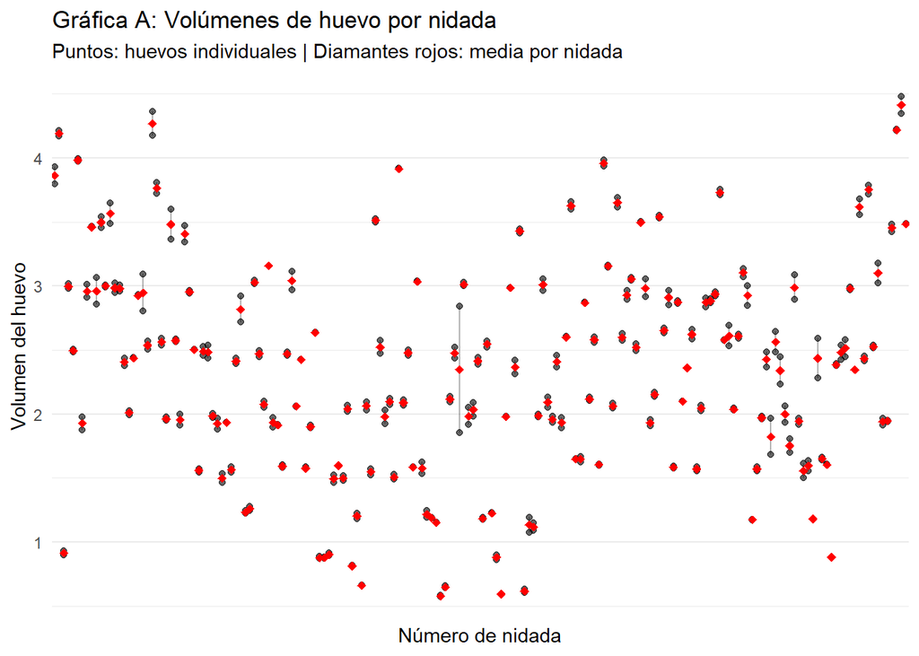

```r
# Versión 1: Puntos individuales (Figura A)
fig_a <- ggplot(coots, aes(x = as.factor(clutch), y = volume)) +
  geom_point(alpha = 0.6, size = 1.5) +
  geom_line(aes(group = clutch), alpha = 0.3) +
  stat_summary(fun = mean, geom = "point",
               color = "red", size = 2, shape = 18) +
  labs(
    title = "Gráfica A: Volúmenes de huevo por nidada",
    subtitle = "Puntos: huevos individuales | Diamantes rojos: media por nidada",
    x = "Número de nidada",
    y = "Volumen del huevo"
  ) +
  theme_minimal() +
  theme(
    axis.text.x = element_blank(),
    axis.ticks.x = element_blank(),
    panel.grid.major.x = element_blank(),
    panel.grid.minor.x = element_blank()
  )

fig_a
```

**Figura B: Distribución de las Medias** Esta gráfica aísla las medias de cada nido. La dispersión que vemos aquí representa la **varianza entre conglomerados**, que es el componente principal de nuestro error de muestreo.

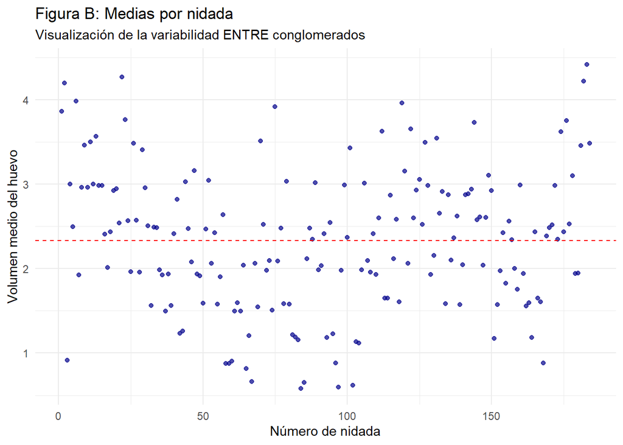

```r
# Figura B: Solo medias (Basado en 50-Conglomerados2.Rmd)
fig_b <- ggplot(resumen_nidadas, aes(x = clutch, y = media)) +
  geom_point(alpha = 0.7, size = 1.5, color = "darkblue") +
  geom_hline(yintercept = mean(resumen_nidadas$media),
             linetype = "dashed", color = "red") +
  labs(
    title = "Figura B: Medias por nidada",
    subtitle = "Visualización de la variabilidad ENTRE conglomerados",
    x = "Número de nidada",
    y = "Volumen medio del huevo"
  ) +
  theme_minimal()

fig_b
```

## 4. Estimación Puntual

**Tarea 2: Estimar el promedio poblacional del volumen del huevo.**

Al tener conglomerados de distintos tamaños ($M_i$ variable), el promedio simple de las medias de los nidos es un estimador sesgado. Debemos usar el Estimador de Razón ($\hat{\bar{Y}}_R$), que pondera cada media por el tamaño de su nido.

```r
# Numerador: Suma de los totales estimados por nido (M_i * media_i)
numerador <- sum(resumen_nidadas$M_i * resumen_nidadas$media)

# Denominador: Suma de los tamaños de los nidos
denominador <- sum(resumen_nidadas$M_i)

# Estimador de Razón
promedio_ponderado <- numerador / denominador

cat("El volumen promedio estimado (Ponderado) es:", round(promedio_ponderado, 4))
```

```
## El volumen promedio estimado (Ponderado) es: 2.4905
```

Comparación con el promedio simple (Sesgado)

```r
promedio_simple <- mean(resumen_nidadas$media)
cat("Promedio Simple (Sin ponderar):", round(promedio_simple, 4), "\n")
```

```
## Promedio Simple (Sin ponderar): 2.3334
```

```r
cat("Diferencia:", round(promedio_ponderado - promedio_simple, 4))
```

```
## Diferencia: 0.1571
```

## 5. Estimación del Error Estándar (SE)

**Tarea 3: Investigar y calcular el error estándar del estimador.**

Dado que usamos un estimador de razón, el error estándar también cambia. Ya no usamos la varianza simple de las medias, sino la varianza de los residuos ponderados.

La fórmula aproximada para el Error Estándar del estimador de razón en muestreo por conglomerados es:

$$SE(\hat{\bar{Y}}_R) \approx
\frac{1}{\bar{M}} \sqrt{\frac{s_r^2}{n}}$$

Donde:

- $\bar{M}$ es el tamaño promedio de los nidos en la muestra.
- $s_r^2$ es la varianza de los valores $u_i$, donde $u_i = M_i (\bar{y}_i - \hat{\bar{Y}}_R)$.
- $n$ es el número de nidos.

Este método captura la variabilidad “entre” conglomerados ajustada por su tamaño.

```r
# 1. Definir n (número de nidos)
n_clutches <- nrow(resumen_nidadas)

# 2. Calcular M promedio (tamaño promedio del nido)
M_bar <- mean(resumen_nidadas$M_i)

# 3. Calcular la variable auxiliar u_i (Residuos ponderados)
# u_i representa cuánto se desvía el total del nido i respecto a lo esperado por el promedio global
resumen_nidadas <- resumen_nidadas %>%
  mutate(u_i = M_i * (media - promedio_ponderado))

# 4. Calcular la varianza de u_i (s_r^2)
s2_r <- var(resumen_nidadas$u_i)

# 5. Calcular Error Estándar (SE)
error_estandar_ratio <- (1 / M_bar) * sqrt(s2_r / n_clutches)

cat("Número de nidadas (n):", n_clutches, "\n")
```

```
## Número de nidadas (n): 184
```

```r
cat("Tamaño promedio del nido (M_bar):", round(M_bar, 2), "\n")
```

```
## Tamaño promedio del nido (M_bar): 9.55
```

```r
cat("Error Estándar (SE) corregido:", round(error_estandar_ratio, 4))
```

```
## Error Estándar (SE) corregido: 0.061
```

**Comparación de Errores**

```r
# Recalculamos el anterior para comparar
sd_entre_nidadas <- sd(resumen_nidadas$media)
se_simple <- sd_entre_nidadas / sqrt(n_clutches)

cat("SE (Método Simple - Incorrecto para M variable):", round(se_simple, 4), "\n")
```

```
## SE (Método Simple - Incorrecto para M variable): 0.0618
```

```r
cat("SE (Método de Razón - Correcto):", round(error_estandar_ratio, 4), "\n")
```

```
## SE (Método de Razón - Correcto): 0.061
```

**Interpretación:** El cálculo correcto ajusta la incertidumbre considerando que los nidos más grandes tienen más peso en la estimación final.

## 6. Intervalo de Confianza

Finalmente, reportamos el resultado con un intervalo de confianza al 95%.

```r
alpha <- 0.05
t_value <- qt(1 - alpha/2, df = n_clutches - 1)

lim_inf <- promedio_ponderado - t_value * error_estandar_ratio
lim_sup <- promedio_ponderado + t_value * error_estandar_ratio

cat("Intervalo de Confianza 95%: [", round(lim_inf, 3), ", ", round(lim_sup, 3), "]")
```

```
## Intervalo de Confianza 95%: [ 2.37 ,  2.611 ]
```

**Reporte Final:** Utilizando un estimador de razón para corregir por los tamaños variables de las nidadas, se estima que el volumen promedio de los huevos en la población es de 2.49 pulgadas cúbicas, con un error estándar de 0.061.